# Дисперсионный анализ

Тимофеев Игорь, 391 гр.

14 ноября 2016 г

## Изучить влияние престижности района и типа постройки на площадь жилья(3п2)

## Гипотезы

Нулевая гипотеза: Престижность района и тип постройки статистически значимо не влияют на площадь жилья.

Альтернативная гипотеза: Существуют такие две группы из 4-х(00,01,10,11 - варианты комбинаций значений номинативных переменных, где первое - NE, второе - CUST), для которых площадь жилья статистически значимо отличается от площади для двух других.

Или иначе говоря, существуют такие две группы, на которые можно разбить множество начальных данных(каждая из которых состоит из каких-то двух начальных групп), что межгрупповая дисперсия будет в значительное число раз больше, чем внутригрупповая, с учетом степеней свободы.

Степень “значительности” определяется вероятностью того, что F значение для двух случайных выборок(по кол-ву совпадающих с нашими группами) из нормального распределения(со средним значением и среднеквадратичным отклонением из наших данных) будет больше вычисленного.

Уровень значимости $\alpha$ зададим равным 0.05.

Т.о. если p значение будет ниже 0.05, то можно считать, что F значение достаточно большое, чтобы считать статистически значимыми межгрупповые различия.

Сначала приведем данные к удобно для нас виду.

```r
str(Albuq_Up)
```

```
## 'data.frame':    117 obs. of  3 variables:
##  $ SQFT: int  2650 2600 2664 2921 2580 2580 2774 1920 2150 1710 ...
##  $ NE  : Factor w/ 2 levels "0","1": 2 2 2 2 2 2 2 2 2 2 ...
##  $ CUST: Factor w/ 2 levels "0","1": 2 2 2 2 2 1 1 2 1 2 ...
```

Теперь посмотрим на вид наших данных с помощью графиков.

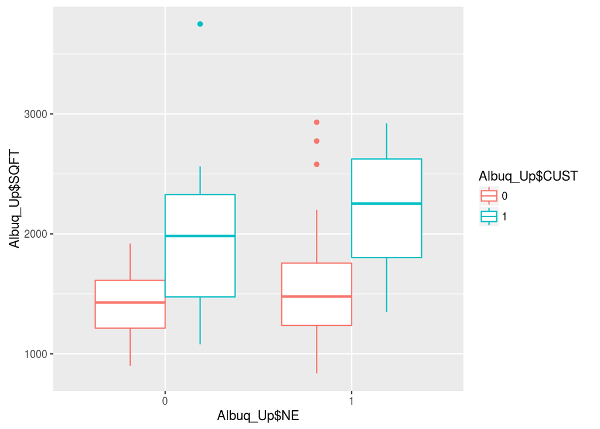

```r
boxplot_Albuq_Up
```

По boxplot можно заметить, что престижность района не сильно влияет на значения площади, а вот необычный тип постройки соответствует большей площади.

```r
stat_summary_Albuq_Up
```

```
## No summary function supplied, defaulting to `mean_se()
```

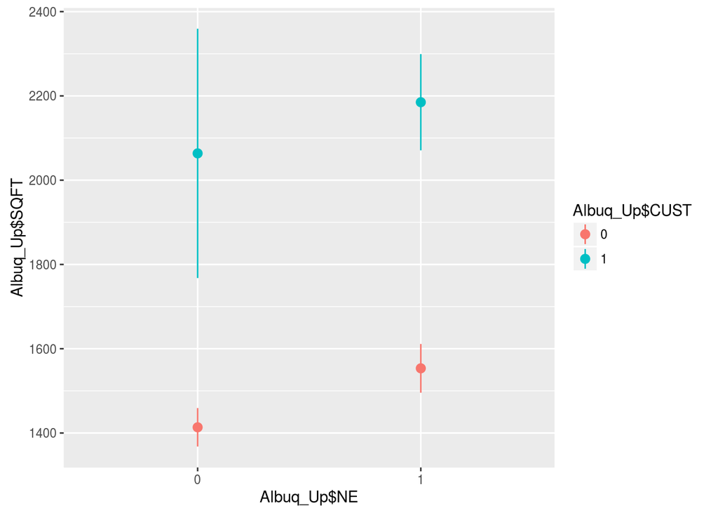

На графике с доверительными интервалами все же заметно сильное отличие между группами с обычным типом постройки и разными уровнями престижности, но для домов с необычным типом постройки это различие уже находится в рамках допустимого отклонения. Тогда как различия между группами обычного и необчного типа постройки - довольно сильное.

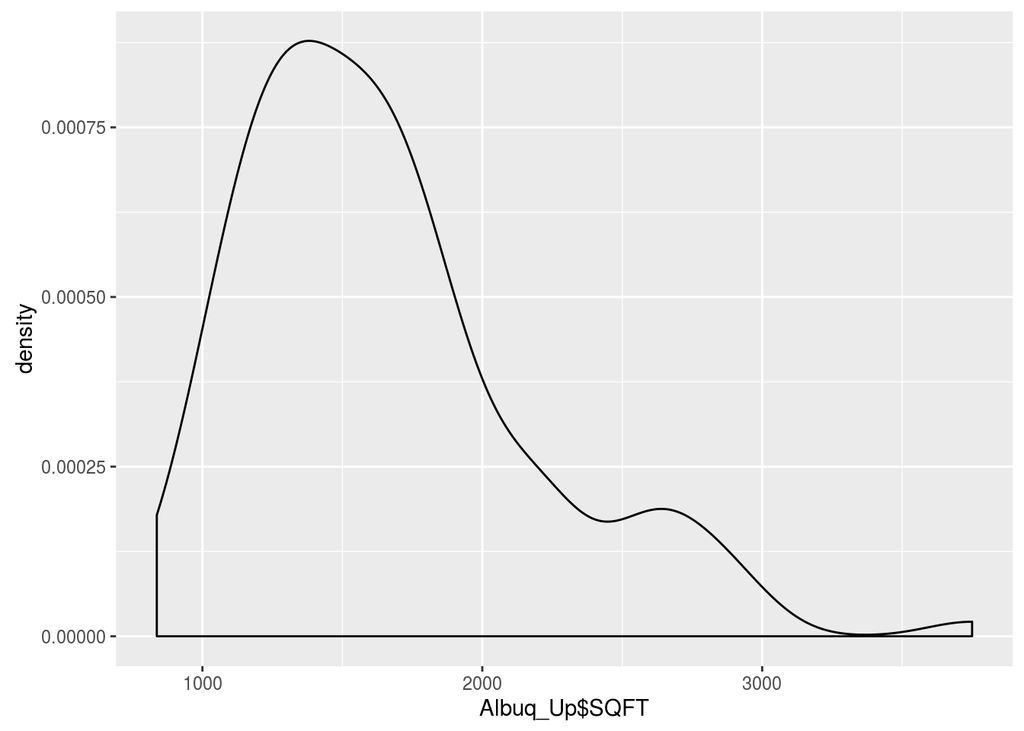

```r
density_all_Albuq_Up
```

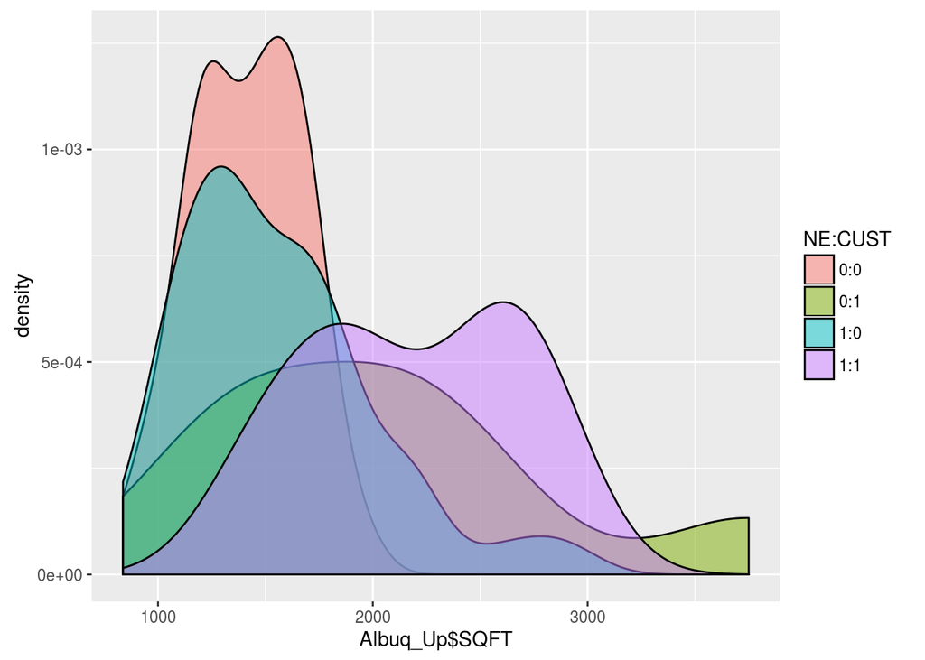

```r
density_NE_CUST_Albuq_Up
```

По этик графикам можно предположить, что наше распределение не очень нормально. Точнее его части соотвествующие 00 и 10.

Проверим это с помощью Шапиро теста.

```r
shtest_00
```

```
##
##  Shapiro-Wilk normality test
##
## data:  Albuq_Up$SQFT[Albuq_Up$NE == "0" & Albuq_Up$CUST == "0"]
## W = 0.97691, p-value = 0.7226
```

```r
shtest_01
```

```
##
##  Shapiro-Wilk normality test
##
## data:  Albuq_Up$SQFT[Albuq_Up$NE == "0" & Albuq_Up$CUST == "1"]
## W = 0.9253, p-value = 0.4743
```

```r
shtest_10
```

```
##
##  Shapiro-Wilk normality test
##
## data:  Albuq_Up$SQFT[Albuq_Up$NE == "1" & Albuq_Up$CUST == "0"]
## W = 0.9303, p-value = 0.00226
```

```r
shtest_11
```

```
##
##  Shapiro-Wilk normality test
##
## data:  Albuq_Up$SQFT[Albuq_Up$NE == "1" & Albuq_Up$CUST == "1"]
## W = 0.94031, p-value = 0.2671
```

Для случая 10 все плохо - распределение далеко от нормального.

Применим уже знакомый алгоритм Бокса Кокса с $\lambda$ = -0.5, получили новые данные Albuq_Up_BoxCox.

Теперь посмотрим, что покажут их графики.

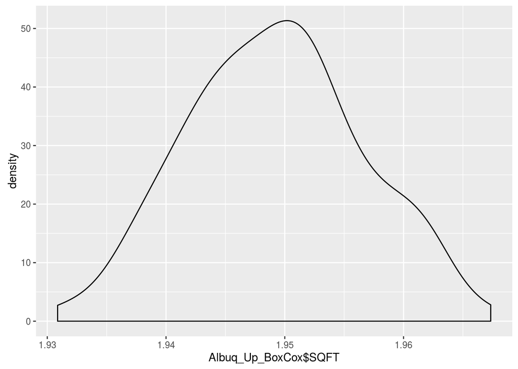

```r
density_all_Albuq_Up_BoxCox
```

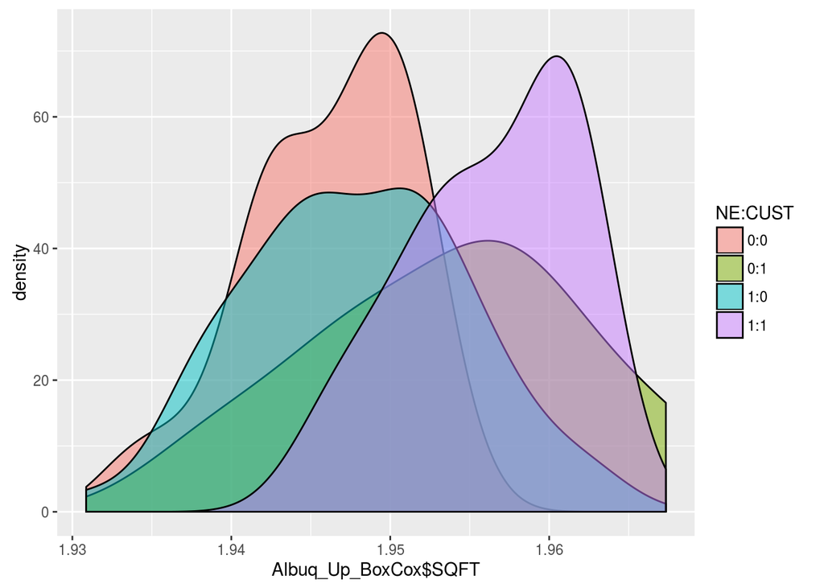

```r
density_NE_CUST_Albuq_Up_BoxCox
```

Теперь распределение уже больше похожи на нормальные.

Хотя график 11 может вызывать сомнения.

Проверим на Шапиро тест.

```r
shtest_00_BoxCox
```

```
##
##  Shapiro-Wilk normality test
##
## data:  Albuq_Up_BoxCox$SQFT[Albuq_Up_BoxCox$NE == "0" & Albuq_Up_BoxCox$CUST ==     "0"]
## W = 0.95318, p-value = 0.1909
```

```r
shtest_01_BoxCox
```

```
##
##  Shapiro-Wilk normality test
##
## data:  Albuq_Up_BoxCox$SQFT[Albuq_Up_BoxCox$NE == "0" & Albuq_Up_BoxCox$CUST ==     "1"]
## W = 0.98925, p-value = 0.9938
```

```r
shtest_10_BoxCox
```

```
##
##  Shapiro-Wilk normality test
##
## data:  Albuq_Up_BoxCox$SQFT[Albuq_Up_BoxCox$NE == "1" & Albuq_Up_BoxCox$CUST ==     "0"]
## W = 0.98985, p-value = 0.9047
```

```r
shtest_11_BoxCox
```

```
##
##  Shapiro-Wilk normality test
##
## data:  Albuq_Up_BoxCox$SQFT[Albuq_Up_BoxCox$NE == "1" & Albuq_Up_BoxCox$CUST ==     "1"]
## W = 0.92532, p-value = 0.1419
```

В результате - все распределения нормальные.

Проверим гомогенность дисперсий.

```r
disptest_CUST
```

```
##
##  Bartlett test of homogeneity of variances
##
## data:  SQFT by CUST
## Bartlett's K-squared = 0.010401, df = 1, p-value = 0.9188
```

```r
disptest_NE
```

```
##
##  Bartlett test of homogeneity of variances
##
## data:  SQFT by NE
## Bartlett's K-squared = 0.63801, df = 1, p-value = 0.4244
```

Здесь все тоже в порядке. Можно запустить итоговый алгоритм AOV и вывести таблицу.

```r
disp
```

```
##              Df   Sum Sq   Mean Sq F value   Pr(>F)
## NE            1 0.000129 0.0001289   3.139   0.0791 .
## CUST          1 0.001402 0.0014016  34.143 5.03e-08 ***
## NE:CUST       1 0.000004 0.0000038   0.092   0.7623
## Residuals   113 0.004639 0.0000411
## ---
## Signif. codes:  0 '***' 0.001 '**' 0.01 '*' 0.05 '.' 0.1 ' ' 1
```

Видно, что как мы и предполагали, смотря на графики, именно по переменной CUST, обозначающей тип постройки, межгрупповое отклонение очень большое. И так как наше $\alpha$ было равно 0.05, то мы смело можем отклонить Нулевую гипотезу.